# TRABAJO FIN DE MÁSTER: DETECCIÓN TEMPRANA DE SEPSIS

**Autor:** Jesús Guerrero Quirós

**Tutores del trabajo:** Juan Antonio Nepomuceno Chamorro y Juan Antonio Nepomuceno Chamorro

**Titulación:** Máster Oficial en Ingeniería Biomédica y Salud Digital

**Centro:** Escuela Técnica Superior de Ingeniería Informática

Universidad de Sevilla | Curso 2022/2023

# **VARIABLE: VASOPRESSORS**

En este notebook se llevará a cabo el estudio de la variable objetivo *Vasopressors*. Esta variable indica la presencia - o no - de vasopresores, que se necesitan cuando se produce un shock séptico.

Por lo tanto, indirectamente, nos está indicando si el paciente sufre un shock séptico.

Se trata de una variable categórica binaria, que puede adquirir los siguientes valores:

- 1 = SÍ
- 2 = NO

Al tratarse de una variable categórica, aplicaremos algoritmos de **clasificación.**

```r
rm(list = ls())
```

```r
library(AlgDesign)
library(dplyr)
library(ggplot2)
library(lubridate)
library(scales)
library(powerMediation)
library(readr)
library(tidyverse)
library(arules)
library(caret)
library(rpart)
library(rattle)
library(RColorBrewer)
library(ROCR)
```

## **1. CARGA DE DATOS**

Utilizaremos el dataset ya cargado del notebook de introducción, ya que incluye varias modificaciones que son necesarias para avanzar.

```r
data_vasopressor <- dataset
```

Como en este notebook vamos a tomar la variable *Vasopressors* como variable dependiente, es conveniente eliminar las demás variables objetivo:

```r
data_vasopressor <- data_vasopressor %>%
  mutate(SOFA.score = NULL) %>%
  mutate(Outcome = NULL)
```

Así, nos queda un dataset con 36 variables, siendo solamente una de ellas la variable dependiente: *Vasopressors*.

```r
dim(data_vasopressor)
```

```
[1] 364  36
```

Cambiamos el valor de la variable dependiente por valores que no sean numéricos:

```r
data_vasopressor <- data_vasopressor %>%
  mutate(Vasopressors = ifelse(Vasopressors==1, "SI", "NO"))
```

## **2. VALIDACIÓN CRUZADA**

Antes de comenzar con los algoritmos de clasificación y regresión, vamos a aplicar validación cruzada con ayuda de la función **trainControl** del paquete Caret:

```r
CV_vasopressors <- trainControl(method = "cv",
                                number = 10,
                                summaryFunction = twoClassSummary,
                                classProbs = TRUE,
                                savePredictions = TRUE,
                                verbose = FALSE)
```

```r
help("trainControl")
```

## **3. ENTRENAMIENTO Y TEST**

A continuación, dividiremos nuestro dataset en dos conjuntos: entrenamiento y test. En este caso, vamos a establecer un 70% para training y un 30% para test.

```r
help("createDataPartition")
```

```r
set.seed(14)

indice <- createDataPartition(data_vasopressor$Vasopressors, p=0.70, list = FALSE)  # Partición de los datos
train_vasopressor <- data_vasopressor[indice,]  # Dataset de entrenamiento
test_vasopressor <- data_vasopressor[-indice,]  # Dataset de test
```

## **4. ÁRBOL DE DECISIÓN**

En primer lugar, entrenamos nuestro modelo:

```r
set.seed(14)

vasopressors_tree_train <- train(as.factor(Vasopressors) ~ .,
                  data = train_vasopressor,
                  method = "rpart",
                  trControl = CV_vasopressors,
                  metric = "ROC")
```

Representamos gráficamente el árbol de decisión resultante del entrenamiento:

```r
suppressMessages(library(rattle))
```

[figure not shown]

```r
fancyRpartPlot(vasopressors_tree_train$finalModel)
```

Utilizamos el modelo para predecir sobre el conjunto de test:

```r
vasopressors_tree_predict <- predict(vasopressors_tree_train, test_vasopressor)
```

Creamos la matriz de confusión:

```r
matriz_tree_vasopressors <- confusionMatrix(as.factor(vasopressors_tree_predict),
                                            as.factor(test_vasopressor$Vasopressors),
                                            mode = "everything")
matriz_tree_vasopressors
```

```
Confusion Matrix and Statistics

          Reference
Prediction NO SI
        NO 74 13
        SI 15  7

               Accuracy : 0.7431
                 95% CI : (0.6506, 0.822)
    No Information Rate : 0.8165
    P-Value [Acc > NIR] : 0.9788

                  Kappa : 0.1747

 Mcnemar's Test P-Value : 0.8501

            Sensitivity : 0.8315
            Specificity : 0.3500
         Pos Pred Value : 0.8506
         Neg Pred Value : 0.3182
              Precision : 0.8506
                 Recall : 0.8315
                     F1 : 0.8409
             Prevalence : 0.8165
         Detection Rate : 0.6789
   Detection Prevalence : 0.7982
      Balanced Accuracy : 0.5907

       'Positive' Class : NO
```

Vamos a calcular también el área bajo la curva:

```r
library(pROC)
```

```r
ROC_dt_vasopressors <- roc(factor(test_vasopressor$Vasopressors), factor(vasopressors_tree_predict, ordered = TRUE))
```

```
Warning: Ordered predictor converted to numeric vector. Threshold values will not correspond to values in predictor.Setting direction: controls < cases
```

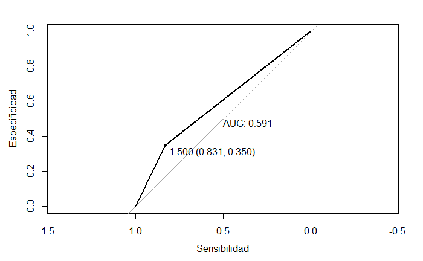

```r
plot.roc(ROC_dt_vasopressors, print.auc = T, print.thres = "best", xlab = "Sensibilidad", ylab = "Especificidad")
```

#### **5. RANDOM FOREST**

En primer lugar, entrenamos nuestro modelo:

```r
set.seed(14)

vasopressors_forest_train <- train(as.factor(Vasopressors) ~ .,
                  data = train_vasopressor,
                  method = "rf",
                  trControl = CV_vasopressors,
                  metric = "ROC")
```

Utilizamos el modelo para predecir sobre el conjunto de test:

```r
vasopressors_forest_predict <- predict(vasopressors_forest_train, test_vasopressor)
```

Creamos la matriz de confusión:

```r
matriz_forest_vasopressors <- confusionMatrix(as.factor(vasopressors_forest_predict),
                                            as.factor(test_vasopressor$Vasopressors),
                                            mode = "everything")
matriz_forest_vasopressors
```

```
Confusion Matrix and Statistics

          Reference
Prediction NO SI
        NO 88 19
        SI  1  1

               Accuracy : 0.8165
                 95% CI : (0.7309, 0.8842)
    No Information Rate : 0.8165
    P-Value [Acc > NIR] : 0.5593970

                  Kappa : 0.0595

 Mcnemar's Test P-Value : 0.0001439

            Sensitivity : 0.9888
            Specificity : 0.0500
         Pos Pred Value : 0.8224
         Neg Pred Value : 0.5000
              Precision : 0.8224
                 Recall : 0.9888
                     F1 : 0.8980
             Prevalence : 0.8165
         Detection Rate : 0.8073
   Detection Prevalence : 0.9817
      Balanced Accuracy : 0.5194

       'Positive' Class : NO
```

Vamos a calcular también el área bajo la curva:

```r
ROC_forest_vasopressors <- roc(factor(test_vasopressor$Vasopressors), factor(vasopressors_forest_predict, ordered = TRUE))
```

```
Warning: Ordered predictor converted to numeric vector. Threshold values will not correspond to values in predictor.Setting direction: controls < cases
```

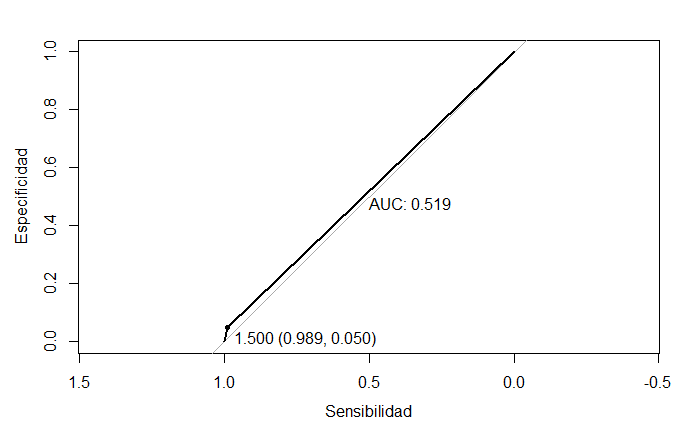

```r
plot.roc(ROC_forest_vasopressors, print.auc = T, print.thres = "best", xlab = "Sensibilidad", ylab = "Especificidad")
```

#### **6. k-NN**

Para el algoritmo kNN (k vecinos más cercanos) es importante tener en cuenta una consideración previa: este algoritmo calcula la similitud entre variables usando la **distancia** entre las mismas. Esto significa que dichas distancias deben ser comparables, y los rangos de valores entre las variables deben ser similares.

Esto implica que debemos **normalizar** algunas de nuestras variables para que funcione el algoritmo. Una manera de hacerlo es definiendo una función y luego aplicarla para las columnas correspondientes de nuestro dataset:

```r
normalizar <- function(variable){
  (variable - min(variable)) / (max(variable) - min(variable))
}
```

```r
datos_normalizados <- data_vasopressor
```

```r
datos_normalizados$Age <- normalizar(datos_normalizados$Age)  # Normalización: EDAD
datos_normalizados$Initial.PCT.value <- normalizar(datos_normalizados$Initial.PCT.value)  # Normalización: PCT VALUE
datos_normalizados$PaO2 <- normalizar(datos_normalizados$PaO2)  # Normalización: PaO2
datos_normalizados$FiO2 <- normalizar(datos_normalizados$FiO2)  # Normalización: FiO2
datos_normalizados$Platelets <- normalizar(datos_normalizados$Platelets)  # Normalización: PLATELETS
datos_normalizados$Bilirubin <- normalizar(datos_normalizados$Bilirubin)  # Normalización: BILIRUBIN
datos_normalizados$GCS <- normalizar(datos_normalizados$GCS)  # Normalización: GCS
datos_normalizados$MAP <- normalizar(datos_normalizados$MAP)  # Normalización: MAP
datos_normalizados$Creatinine <- normalizar(datos_normalizados$Creatinine)  # Normalización: CREATININE
datos_normalizados$UOP <- normalizar(datos_normalizados$UOP)  # Normalización: UOP
datos_normalizados$LOS <- normalizar(datos_normalizados$LOS)  # Normalización: LOS
```

```r
train_vasopressor_knn <- datos_normalizados[indice,]
test_vasopressor_knn <- datos_normalizados[-indice,]
```

En primer lugar, entrenamos nuestro modelo:

```r
set.seed(14)
vasopressors_knn_train_accu <- train(as.factor(Vasopressors) ~ .,
                  data = train_vasopressor,
                  method = "knn",
                  trControl = trainControl(method = "cv"),
                  tuneLength = 20)
```

```r
vasopressors_knn_train_accu
```

```
k-Nearest Neighbors

255 samples
 35 predictor
  2 classes: 'NO', 'SI'

No pre-processing
Resampling: Cross-Validated (10 fold)
Summary of sample sizes: 229, 230, 229, 231, 230, 229, ...
Resampling results across tuning parameters:

  k   Accuracy   Kappa
   5  0.8117949  0.07621064
   7  0.8079487  0.04960824
   9  0.8197949  0.04852021
  11  0.8159487  0.00000000
  13  0.8159487  0.00000000
  15  0.8159487  0.00000000
  17  0.8159487  0.00000000
  19  0.8159487  0.00000000
  21  0.8159487  0.00000000
  23  0.8159487  0.00000000
  25  0.8159487  0.00000000
  27  0.8159487  0.00000000
  29  0.8159487  0.00000000
  31  0.8159487  0.00000000
  33  0.8159487  0.00000000
  35  0.8159487  0.00000000
  37  0.8159487  0.00000000
  39  0.8159487  0.00000000
  41  0.8159487  0.00000000
  43  0.8159487  0.00000000

Accuracy was used to select the optimal model using the largest value.
The final value used for the model was k = 9.
```

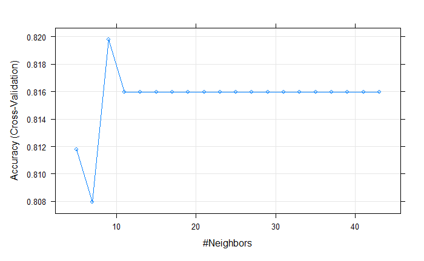

```r
plot(vasopressors_knn_train_accu)
```

Repetimos el algoritmo, pero tomando ROC como métrica:

```r
set.seed(14)
vasopressors_knn_train_ROC <- train(as.factor(Vasopressors) ~ .,
                  data = train_vasopressor,
                  method = "knn",
                  trControl = CV_vasopressors,
                  metric = "ROC",
                  tuneLength = 20)
```

```r
vasopressors_knn_train_ROC
```

```
k-Nearest Neighbors

255 samples
 35 predictor
  2 classes: 'NO', 'SI'

No pre-processing
Resampling: Cross-Validated (10 fold)
Summary of sample sizes: 229, 230, 229, 231, 230, 229, ...
Resampling results across tuning parameters:

  k   ROC        Sens       Spec
   5  0.4681548  0.9759524  0.08
   7  0.4796786  0.9759524  0.06
   9  0.4747321  0.9952381  0.04
  11  0.4778810  1.0000000  0.00
  13  0.4994821  1.0000000  0.00
  15  0.4695536  1.0000000  0.00
  17  0.4859940  1.0000000  0.00
  19  0.4735774  1.0000000  0.00
  21  0.4913155  1.0000000  0.00
  23  0.4957024  1.0000000  0.00
  25  0.5236310  1.0000000  0.00
  27  0.5508095  1.0000000  0.00
  29  0.5429821  1.0000000  0.00
  31  0.5576548  1.0000000  0.00
  33  0.5781071  1.0000000  0.00
  35  0.5755417  1.0000000  0.00
  37  0.5508333  1.0000000  0.00
  39  0.5702083  1.0000000  0.00
  41  0.5836607  1.0000000  0.00
  43  0.5714464  1.0000000  0.00

ROC was used to select the optimal model using the largest value.
The final value used for the model was k = 41.
```

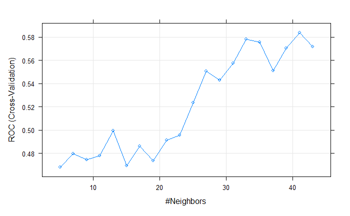

```r
plot(vasopressors_knn_train_ROC)
```

Utilizamos el modelo para predecir sobre el conjunto de test:

```r
vasopressors_knn_predict <- predict(vasopressors_knn_train_ROC, test_vasopressor_knn)
```

```r
matriz_knn_vasopressors <- confusionMatrix(as.factor(vasopressors_knn_predict),
                                            as.factor(test_vasopressor$Vasopressors),
                                            mode = "everything")
matriz_knn_vasopressors
```

```
Confusion Matrix and Statistics

          Reference
Prediction NO SI
        NO 89 20
        SI  0  0

               Accuracy : 0.8165
                 95% CI : (0.7309, 0.8842)
    No Information Rate : 0.8165
    P-Value [Acc > NIR] : 0.5594

                  Kappa : 0

 Mcnemar's Test P-Value : 2.152e-05

            Sensitivity : 1.0000
            Specificity : 0.0000
         Pos Pred Value : 0.8165
         Neg Pred Value :    NaN
              Precision : 0.8165
                 Recall : 1.0000
                     F1 : 0.8990
             Prevalence : 0.8165
         Detection Rate : 0.8165
   Detection Prevalence : 1.0000
      Balanced Accuracy : 0.5000

       'Positive' Class : NO
```

Vamos a calcular también el área bajo la curva:

```r
ROC_knn_vasopressors <- roc(factor(test_vasopressor$Vasopressors), factor(vasopressors_knn_predict, ordered = TRUE))
```

```
Warning: Ordered predictor converted to numeric vector. Threshold values will not correspond to values in predictor.Setting direction: controls < cases
```

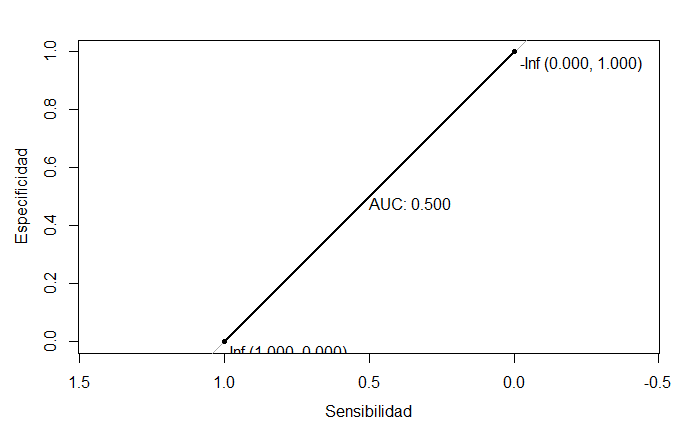

```r
plot.roc(ROC_knn_vasopressors, print.auc = T, print.thres = "best", xlab = "Sensibilidad", ylab = "Especificidad")
```

#### **7. NAIVE-BAYES**

Instalamos las librerías necesarias para aplicar el algoritmo:

```r
library("klaR")
```

```r
library(e1071)
```

Entrenamos nuestro modelo:

```r
set.seed(14)

vasopressors_nb_train <- train(as.factor(Vasopressors) ~ .,
                          data = train_vasopressor,
                          method = "nb",
                          trControl = CV_vasopressors,
                          metric = "ROC",
                          tuneLength = 20)
```

A continuación podemos ver el resultado del entrenamiento:

```r
vasopressors_nb_train
```

```
Naive Bayes

255 samples
 35 predictor
  2 classes: 'NO', 'SI'

No pre-processing
Resampling: Cross-Validated (10 fold)
Summary of sample sizes: 229, 230, 229, 231, 230, 229, ...
Resampling results across tuning parameters:

  usekernel  ROC        Sens       Spec
  FALSE            NaN        NaN  NaN
   TRUE      0.6985476  0.9952381    0

Tuning parameter 'fL' was held constant at a value of 0
Tuning parameter 'adjust' was held constant at a value of 1
ROC was used to select the optimal model using the largest value.
The final values used for the model were fL = 0, usekernel = TRUE and adjust = 1.
```

```r
vasopressors_nb_predict <- predict(vasopressors_nb_train, test_vasopressor)
```

Creamos la matriz de confusión:

```r
matriz_nb_vasopressors <- confusionMatrix(as.factor(vasopressors_nb_predict),
                                            as.factor(test_vasopressor$Vasopressors),
                                            mode = "everything")
matriz_nb_vasopressors
```

```
Confusion Matrix and Statistics

          Reference
Prediction NO SI
        NO 89 20
        SI  0  0

               Accuracy : 0.8165
                 95% CI : (0.7309, 0.8842)
    No Information Rate : 0.8165
    P-Value [Acc > NIR] : 0.5594

                  Kappa : 0

 Mcnemar's Test P-Value : 2.152e-05

            Sensitivity : 1.0000
            Specificity : 0.0000
         Pos Pred Value : 0.8165
         Neg Pred Value :    NaN
              Precision : 0.8165
                 Recall : 1.0000
                     F1 : 0.8990
             Prevalence : 0.8165
         Detection Rate : 0.8165
   Detection Prevalence : 1.0000
      Balanced Accuracy : 0.5000

       'Positive' Class : NO
```

Vamos a calcular también el área bajo la curva:

```r
ROC_nb_vasopressors <- roc(factor(test_vasopressor$Vasopressors), factor(vasopressors_nb_predict, ordered = TRUE))
```

```
Warning: Ordered predictor converted to numeric vector. Threshold values will not correspond to values in predictor.Setting direction: controls < cases
```

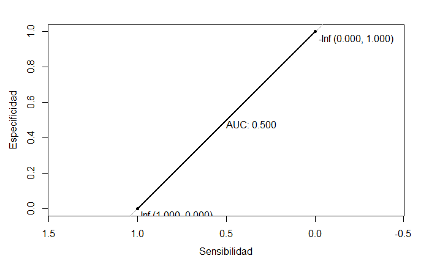

```r
plot.roc(ROC_nb_vasopressors, print.auc = T, print.thres = "best", xlab = "Sensibilidad", ylab = "Especificidad")
```

## **8. MÁQUINA DE VECTORES DE SOPORTE LINEAL**

En primer lugar, entrenamos nuestro modelo:

```r
set.seed(14)

vasopressors_SVM_train <- train(as.factor(Vasopressors) ~ .,
                  data = train_vasopressor,
                  method = "svmLinear",
                  trControl = CV_vasopressors,
                  metric = "ROC",
                  tuneLength = 20)
```

```r
vasopressors_SVM_train
```

```
Support Vector Machines with Linear Kernel

255 samples
 35 predictor
  2 classes: 'NO', 'SI'

No pre-processing
Resampling: Cross-Validated (10 fold)
Summary of sample sizes: 229, 230, 229, 231, 230, 229, ...
Resampling results:

  ROC        Sens       Spec
  0.7374167  0.9902381  0.04

Tuning parameter 'C' was held constant at a value of 1
```

Utilizamos el modelo para predecir sobre el conjunto de test:

```r
vasopressors_SVM_predict <- predict(vasopressors_SVM_train, test_vasopressor)
```

Creamos la matriz de confusión:

```r
matriz_SVM_vasopressors <- confusionMatrix(as.factor(vasopressors_SVM_predict),
                                            as.factor(test_vasopressor$Vasopressors),
                                            mode = "everything")
matriz_SVM_vasopressors
```

```
Confusion Matrix and Statistics

          Reference
Prediction NO SI
        NO 83 16
        SI  6  4

               Accuracy : 0.7982
                 95% CI : (0.7105, 0.869)
    No Information Rate : 0.8165
    P-Value [Acc > NIR] : 0.73716

                  Kappa : 0.1645

 Mcnemar's Test P-Value : 0.05501

            Sensitivity : 0.9326
            Specificity : 0.2000
         Pos Pred Value : 0.8384
         Neg Pred Value : 0.4000
              Precision : 0.8384
                 Recall : 0.9326
                     F1 : 0.8830
             Prevalence : 0.8165
         Detection Rate : 0.7615
   Detection Prevalence : 0.9083
      Balanced Accuracy : 0.5663

       'Positive' Class : NO
```

```r
ROC_SVM_vasopressors <- roc(factor(test_vasopressor$Vasopressors), factor(vasopressors_SVM_predict, ordered = TRUE))
```

```
Warning: Ordered predictor converted to numeric vector. Threshold values will not correspond to values in predictor.Setting direction: controls < cases
```

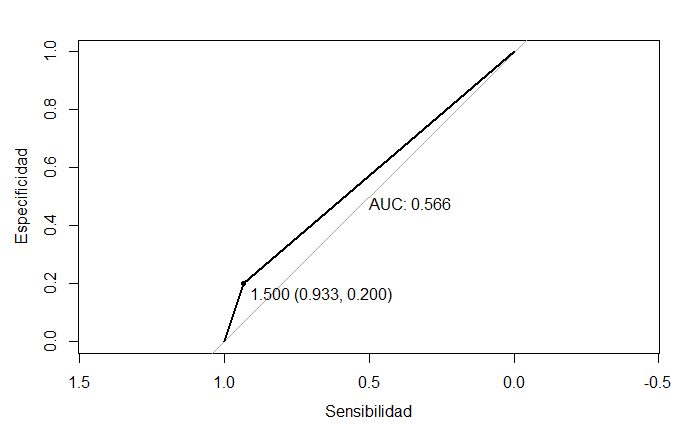

```r
plot.roc(ROC_SVM_vasopressors, print.auc = T, print.thres = "best", xlab = "Sensibilidad", ylab = "Especificidad")
```

## **9. MÁQUINA DE VECTORES DE SOPORTE KERNEL**

En primer lugar, entrenamos nuestro modelo:

```r
set.seed(14)

vasopressors_kernel_train <- train(as.factor(Vasopressors) ~ .,
                  data = train_vasopressor,
                  method = "svmRadial",
                  trControl = CV_vasopressors,
                  metric = "ROC",
                  tuneLength = 20)
```

```
maximum number of iterations reached -0.0004469687 -0.0004205886
```

```
maximum number of iterations reached 0.0001746681 0.000154669
```

```r
vasopressors_kernel_train
```

```
Support Vector Machines with Radial Basis Function Kernel

255 samples
 35 predictor
  2 classes: 'NO', 'SI'

No pre-processing
Resampling: Cross-Validated (10 fold)
Summary of sample sizes: 229, 230, 229, 231, 230, 229, ...
Resampling results across tuning parameters:

  C          ROC        Sens       Spec
       0.25  0.7771310  0.9664286  0.120
       0.50  0.7271310  0.9619048  0.120
       1.00  0.7766548  0.9664286  0.190
       2.00  0.7846071  0.9664286  0.105
       4.00  0.7865476  0.9711905  0.100
       8.00  0.7733333  0.9857143  0.100
      16.00  0.7148333  0.9714286  0.085
      32.00  0.6988571  0.9857143  0.105
      64.00  0.7362381  0.9759524  0.085
     128.00  0.6766667  0.9714286  0.065
     256.00  0.7261905  0.9759524  0.085
     512.00  0.6766667  0.9757143  0.105
    1024.00  0.7261905  0.9759524  0.085
    2048.00  0.6766667  0.9664286  0.110
    4096.00  0.7261905  0.9711905  0.105
    8192.00  0.7261905  0.9614286  0.105
   16384.00  0.6766667  0.9759524  0.065
   32768.00  0.7261905  0.9761905  0.085
   65536.00  0.6766667  0.9807143  0.085
  131072.00  0.7261905  0.9902381  0.105

Tuning parameter 'sigma' was held constant at a value of 0.01863996
ROC was used to select the optimal model using the largest value.
The final values used for the model were sigma = 0.01863996 and C = 4.
```

Utilizamos el modelo para predecir sobre el conjunto de test:

```r
vasopressors_kernel_predict <- predict(vasopressors_kernel_train, test_vasopressor)
```

Creamos la matriz de confusión:

```r
matriz_kernel_vasopressors <- confusionMatrix(as.factor(vasopressors_kernel_predict),
                                            as.factor(test_vasopressor$Vasopressors),
                                            mode = "everything")
matriz_kernel_vasopressors
```

```
Confusion Matrix and Statistics

          Reference
Prediction NO SI
        NO 84 12
        SI  5  8

               Accuracy : 0.844
                 95% CI : (0.7621, 0.9064)
    No Information Rate : 0.8165
    P-Value [Acc > NIR] : 0.2736

                  Kappa : 0.3978

 Mcnemar's Test P-Value : 0.1456

            Sensitivity : 0.9438
            Specificity : 0.4000
         Pos Pred Value : 0.8750
         Neg Pred Value : 0.6154
              Precision : 0.8750
                 Recall : 0.9438
                     F1 : 0.9081
             Prevalence : 0.8165
         Detection Rate : 0.7706
   Detection Prevalence : 0.8807
      Balanced Accuracy : 0.6719

       'Positive' Class : NO
```

```r
ROC_kernel_vasopressors <- roc(factor(test_vasopressor$Vasopressors), factor(vasopressors_kernel_predict, ordered = TRUE))
```

```
Warning: Ordered predictor converted to numeric vector. Threshold values will not correspond to values in predictor.Setting direction: controls < cases
```

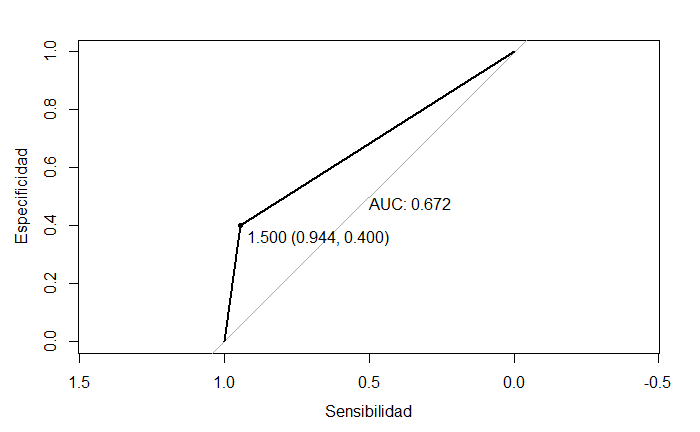

```r
plot.roc(ROC_kernel_vasopressors, print.auc = T, print.thres = "best", xlab = "Sensibilidad", ylab = "Especificidad")
```